# Lab week 1 - R tools

Data Science and Machine Learning 1 - CEU 2018

Jeno Pal

2018-01-09

## Packages

Install necessary packages. We will install more as we progress in the course.

```r
install.packages(c("ggplot2",
                   "readr",
                   "data.table",
                   "purrr",
                   "glmnet",
                   "randomForest",
                   "gbm",
                   "rpart",
                   "caret",
                   "ROCR",
                   "titanic"
                   ))
```

If we want to use packages, we have to import them.

```r
library(data.table)
library(readr)
library(ggplot2)
library(purrr)
```

We will use [`h2o`](https://www.h2o.ai/) in the second part of the course. Its installation requires Java. Once that is installed, run

```r
install.packages("h2o")
```

To test if the installation works, run these:

```r
library(h2o)
h2o.init(nthreads=-1)

dx_train <- h2o.importFile("https://s3.amazonaws.com/benchm-ml--main/train-0.1m.csv")
dx_test <- h2o.importFile("https://s3.amazonaws.com/benchm-ml--main/test.csv")
md <- h2o.randomForest(x = 1:8, y = 9, training_frame = dx_train, ntrees = 50)
h2o.performance(md, dx_test)@metrics$AUC
```

## Workflow with Rmarkdown Notebook

Consult the excellent [cheat sheet](https://www.rstudio.com/wp-content/uploads/2015/02/rmarkdown-cheatsheet.pdf) on Rmarkdown and see the homepage on [notebooks](http://rmarkdown.rstudio.com/r_notebooks.html). For the markdown syntax, again, see the cheatsheet.

In RStudio:

1. `File -> New File -> R Notebook`
2. Add chunks, edit interactively, execude code…
- do not always expect Preview to be 100% correct
3. When all is well, `Knit to HTML`

## Elements of R

Very useful resources: RStudio [cheat sheets](https://www.rstudio.com/resources/cheatsheets/): `ggplot2`, `rmarkdown` and more. For `data.table`, see [here](https://s3.amazonaws.com/assets.datacamp.com/img/blog/data+table+cheat+sheet.pdf). Building on [DA1](https://github.com/daroczig/CEU-R-lab) we are going to use `data.table` for data munging, `ggplot2` for visualization and `rmarkdown` for preparing notes (homeworks).

### Loading data

From data packages, reading csvs - `readr::read_csv`, `data.table::fread`.

```r
# there are packages that contain data
library(titanic)
titanic_train
```

```r
# readr reads into a decorated dataframe, a "tibble"
# -- same data that is packaged to the `titanic` package, both from Kaggle
df <- read_csv("../../data/titanic/train.csv")
str(df)
```

```
## Classes 'tbl_df', 'tbl' and 'data.frame':    891 obs. of  12 variables:
##  $ PassengerId: int  1 2 3 4 5 6 7 8 9 10 ...
##  $ Survived   : int  0 1 1 1 0 0 0 0 1 1 ...
##  $ Pclass     : int  3 1 3 1 3 3 1 3 3 2 ...
##  $ Name       : chr  "Braund, Mr. Owen Harris" "Cumings, Mrs. John Bradley (Florence Briggs Thayer)" "Heikkinen, Miss. Laina" "Futrelle, Mrs. Jacques Heath (Lily May Peel)" ...
##  $ Sex        : chr  "male" "female" "female" "female" ...
##  $ Age        : num  22 38 26 35 35 NA 54 2 27 14 ...
##  $ SibSp      : int  1 1 0 1 0 0 0 3 0 1 ...
##  $ Parch      : int  0 0 0 0 0 0 0 1 2 0 ...
##  $ Ticket     : chr  "A/5 21171" "PC 17599" "STON/O2. 3101282" "113803" ...
##  $ Fare       : num  7.25 71.28 7.92 53.1 8.05 ...
##  $ Cabin      : chr  NA "C85" NA "C123" ...
##  $ Embarked   : chr  "S" "C" "S" "S" ...
##  - attr(*, "spec")=List of 2
##   ..$ cols   :List of 12
##   .. ..$ PassengerId: list()
##   .. .. ..- attr(*, "class")= chr  "collector_integer" "collector"
##   .. ..$ Survived   : list()
##   .. .. ..- attr(*, "class")= chr  "collector_integer" "collector"
##   .. ..$ Pclass     : list()
##   .. .. ..- attr(*, "class")= chr  "collector_integer" "collector"
##   .. ..$ Name       : list()
##   .. .. ..- attr(*, "class")= chr  "collector_character" "collector"
##   .. ..$ Sex        : list()
##   .. .. ..- attr(*, "class")= chr  "collector_character" "collector"
##   .. ..$ Age        : list()
##   .. .. ..- attr(*, "class")= chr  "collector_double" "collector"
##   .. ..$ SibSp      : list()
##   .. .. ..- attr(*, "class")= chr  "collector_integer" "collector"
##   .. ..$ Parch      : list()
##   .. .. ..- attr(*, "class")= chr  "collector_integer" "collector"
##   .. ..$ Ticket     : list()
##   .. .. ..- attr(*, "class")= chr  "collector_character" "collector"
##   .. ..$ Fare       : list()
##   .. .. ..- attr(*, "class")= chr  "collector_double" "collector"
##   .. ..$ Cabin      : list()
##   .. .. ..- attr(*, "class")= chr  "collector_character" "collector"
##   .. ..$ Embarked   : list()
##   .. .. ..- attr(*, "class")= chr  "collector_character" "collector"
##   ..$ default: list()
##   .. ..- attr(*, "class")= chr  "collector_guess" "collector"
##   ..- attr(*, "class")= chr "col_spec"
```

```r
# fread: for large csvs very fast and reliable. Reads to data.table
dt <- fread("../../data/titanic/train.csv")
str(dt)
```

```
## Classes 'data.table' and 'data.frame':   891 obs. of  12 variables:
##  $ PassengerId: int  1 2 3 4 5 6 7 8 9 10 ...
##  $ Survived   : int  0 1 1 1 0 0 0 0 1 1 ...
##  $ Pclass     : int  3 1 3 1 3 3 1 3 3 2 ...
##  $ Name       : chr  "Braund, Mr. Owen Harris" "Cumings, Mrs. John Bradley (Florence Briggs Thayer)" "Heikkinen, Miss. Laina" "Futrelle, Mrs. Jacques Heath (Lily May Peel)" ...
##  $ Sex        : chr  "male" "female" "female" "female" ...
##  $ Age        : num  22 38 26 35 35 NA 54 2 27 14 ...
##  $ SibSp      : int  1 1 0 1 0 0 0 3 0 1 ...
##  $ Parch      : int  0 0 0 0 0 0 0 1 2 0 ...
##  $ Ticket     : chr  "A/5 21171" "PC 17599" "STON/O2. 3101282" "113803" ...
##  $ Fare       : num  7.25 71.28 7.92 53.1 8.05 ...
##  $ Cabin      : chr  "" "C85" "" "C123" ...
##  $ Embarked   : chr  "S" "C" "S" "S" ...
##  - attr(*, ".internal.selfref")=<externalptr>
```

### Data manipulation

Filtering, selecting, adding new variables, grouping, aggregation, random sampling, counting unique elements.

```r
dt <- data.table(titanic_train)
```

```r
# filter only male
dt[Sex == "male"]
```

| PassengerId | Survived | Pclass | Name | Sex | Age | SibSp | Parch | Ticket | Fare | Cabin | Embarked |
| --- | --- | --- | --- | --- | --- | --- | --- | --- | --- | --- | --- |
| 1 | 0 | 3 | Braund, Mr. Owen Harris | male | 22.00 | 1 | 0 | A/5 21171 | 7.2500 |  | S |
| 5 | 0 | 3 | Allen, Mr. William Henry | male | 35.00 | 0 | 0 | 373450 | 8.0500 |  | S |
| 6 | 0 | 3 | Moran, Mr. James | male | NA | 0 | 0 | 330877 | 8.4583 |  | Q |
| 7 | 0 | 1 | McCarthy, Mr. Timothy J | male | 54.00 | 0 | 0 | 17463 | 51.8625 | E46 | S |
| 8 | 0 | 3 | Palsson, Master. Gosta Leonard | male | 2.00 | 3 | 1 | 349909 | 21.0750 |  | S |
| 13 | 0 | 3 | Saundercock, Mr. William Henry | male | 20.00 | 0 | 0 | A/5. 2151 | 8.0500 |  | S |
| 14 | 0 | 3 | Andersson, Mr. Anders Johan | male | 39.00 | 1 | 5 | 347082 | 31.2750 |  | S |
| 17 | 0 | 3 | Rice, Master. Eugene | male | 2.00 | 4 | 1 | 382652 | 29.1250 |  | Q |
| 18 | 1 | 2 | Williams, Mr. Charles Eugene | male | NA | 0 | 0 | 244373 | 13.0000 |  | S |
| 21 | 0 | 2 | Fynney, Mr. Joseph J | male | 35.00 | 0 | 0 | 239865 | 26.0000 |  | S |

[output cut: 567 more lines]

```r
# select columns
dt[, .(Sex, Survived)]
```

| Sex | Survived |
| --- | --- |
| male | 0 |
| female | 1 |
| female | 1 |
| female | 1 |
| male | 0 |
| male | 0 |
| male | 0 |
| male | 0 |
| female | 1 |
| female | 1 |

[output cut: 881 more lines]

```r
# add a new variable
dt[, SurvivedInfo := ifelse(Survived == 1, "survived", "did not survive")]
head(dt[, .(Survived, SurvivedInfo)])
```

| Survived | SurvivedInfo |
| --- | --- |
| 0 | did not survive |
| 1 | survived |
| 1 | survived |
| 1 | survived |
| 0 | did not survive |
| 0 | did not survive |

```r
# delete variable
dt[, SurvivedInfo := NULL]
```

```r
# aggregate by groups
dt_measures <- dt[, .(num_passangers = .N,
       num_survivors = sum(Survived)),
   by = .(Sex)]
```

```r
# reshape data from wide to long format
dt_measures_long <- melt(dt_measures,
                         id.vars = "Sex",
                         measures.vars = c("num_passangers", "num_survivors"))
dt_measures_long
```

| Sex | variable | value |
| --- | --- | --- |
| male | num_passangers | 577 |
| female | num_passangers | 314 |
| male | num_survivors | 109 |
| female | num_survivors | 233 |

```r
# from long to wide
dcast(dt_measures_long, Sex ~ variable, direction = "wide")
```

| Sex | num_passangers | num_survivors |
| --- | --- | --- |
| female | 314 | 233 |
| male | 577 | 109 |

### Loops, maps

For loop, lapply, sapply, purrr maps

```r
for (number in 1:5) {
  print(number * 2)
}
```

```
## [1] 2
## [1] 4
## [1] 6
## [1] 8
## [1] 10
```

```r
# using the purrr package
walk(1:5, ~{ print(.x * 2)})
```

```
## [1] 2
## [1] 4
## [1] 6
## [1] 8
## [1] 10
```

```r
# if you want to keep the result in a list
doubled <- map(1:5, ~ { .x * 2})
str(doubled)
```

```
## List of 5
##  $ : num 2
##  $ : num 4
##  $ : num 6
##  $ : num 8
##  $ : num 10
```

```r
# or as a vector:
doubled_vec <- map_dbl(1:5, ~ { .x * 2})
str(doubled_vec)
```

```
##  num [1:5] 2 4 6 8 10
```

### Visualization

We are going to use `ggplot2`.

### Exercise: preparing a calibration plot

```r
# make a simple model for survival using logistic regression
model <- glm(Survived ~ Sex + Fare, data = dt, family = binomial)
prediction <- predict.glm(model, newdata = dt, type = "response")
dt[, Survived_Score := prediction]
```

```r
# bin people according to their scores
dt[, Survived_Score_Category := cut(Survived_Score, seq(0, 1, 0.1))]

# calculate mean of score and truth in categories
calibration <- dt[,
      .(mean_score = mean(Survived_Score),
        mean_truth = mean(Survived),
        num_people = .N),
       keyby = Survived_Score_Category]
```

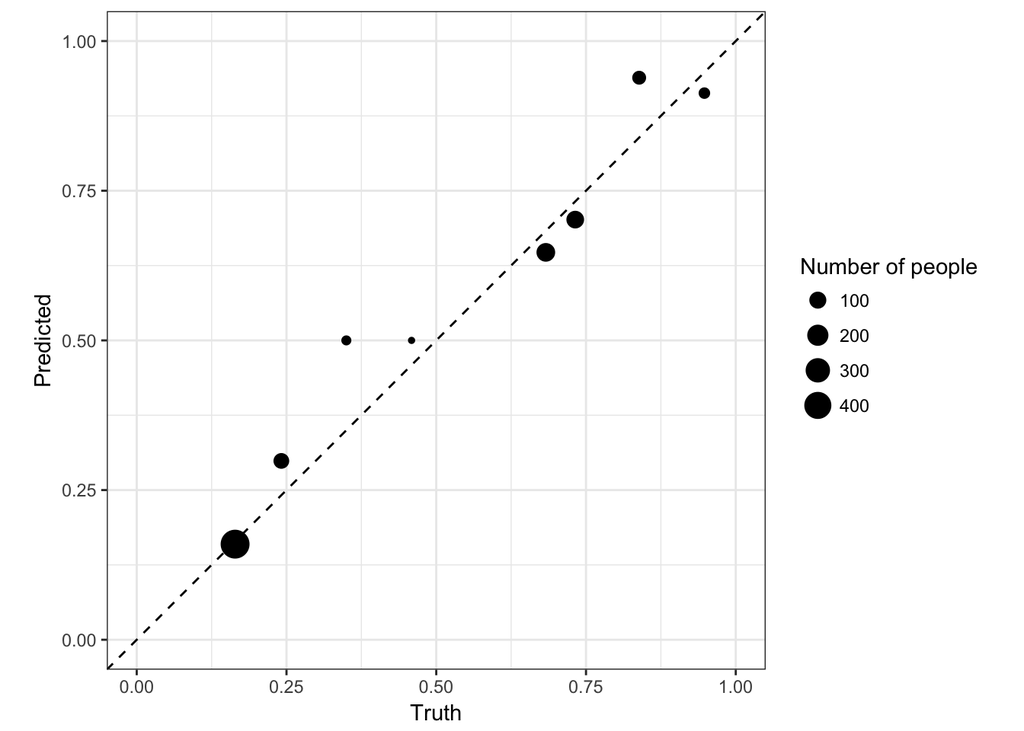

```r
# add the lines step by step and see how the figure becomes nicer and nicer!
ggplot(data = calibration,
       aes(x = mean_score, y = mean_truth, size = num_people)) +
  geom_point() +
  geom_abline(intercept = 0, slope = 1, linetype = "dashed") +
  xlim(0, 1) +
  ylim(0, 1) +
  coord_fixed(ratio = 1) +
  labs(x = "Truth",
       y = "Predicted",
       size = "Number of people") +
  theme_bw()
```

### Reproducibility

For yourself, for others. What is necessary for anyone else to reproduce my analysis?

- others do not have the same directory structure: use relative paths instead of absolute
- others do not necessarily use the same R and package versions
  - provide `sessionInfo()`
  - use some tool (out of the scope of this course. Examples: [`packrat`](https://rstudio.github.io/packrat/) package, [MRAN](https://mran.revolutionanalytics.com/) time machine)
- if I use random numbers, I have to ensure others use the same random numbers
- simplest case: use `set.seed`

## Recommended readings

- [Elements of Statistical Learning](https://web.stanford.edu/~hastie/ElemStatLearn/) - the standard reference book of machine learning (freely available)
- [Introduction to Statistical Learning](http://www-bcf.usc.edu/~gareth/ISL/) - a more accessible treatment of the same material from the same authors (with R codes)
- [Applied Predictive Modelling](http://appliedpredictivemodeling.com/) - a thorough and practical guide to predictive modelling from the author of the `caret` package (with R code)